# Lab 4B : Data wrangling and graphing COVID-19 reporting data (Part 1)

Jarrod Daniels

9/14/2020

## R Markdown

```r
report_03_11_2020 <-   read_csv(url("https://raw.githubusercontent.com/CSSEGISandData/COVID-19/master/csse_covid_19_data/csse_covid_19_daily_reports/03-11-2020.csv")) %>%
  rename(Country_Region = "Country/Region", Province_State = "Province/State")
str(report_03_11_2020)
```

```
## Classes 'spec_tbl_df', 'tbl_df', 'tbl' and 'data.frame': 216 obs. of  8 variables:
##  $ Province_State: chr  "Hubei" NA NA NA ...
##  $ Country_Region: chr  "China" "Italy" "Iran" "Korea, South" ...
##  $ Last Update   : POSIXct, format: "2020-03-11 10:53:02" "2020-03-11 21:33:02" ...
##  $ Confirmed     : num  67773 12462 9000 7755 2281 ...
##  $ Deaths        : num  3046 827 354 60 48 ...
##  $ Recovered     : num  49134 1045 2959 288 12 ...
##  $ Latitude      : num  31 43 32 36 46.2 ...
##  $ Longitude     : num  112.27 12 53 128 2.21 ...
##  - attr(*, "spec")=
##   .. cols(
##   ..   `Province/State` = col_character(),
##   ..   `Country/Region` = col_character(),
##   ..   `Last Update` = col_datetime(format = ""),
##   ..   Confirmed = col_double(),
##   ..   Deaths = col_double(),
##   ..   Recovered = col_double(),
##   ..   Latitude = col_double(),
##   ..   Longitude = col_double()
##   .. )
```

```r
View(report_03_11_2020)
```

## Interactive Data Tables

```r
library(DT)
datatable(report_03_11_2020)
```

|  | Province_State | Country_Region | Last Update | Confirmed | Deaths | Recovered | Latitude | Longitude |
| --- | --- | --- | --- | --- | --- | --- | --- | --- |
| 1 | Hubei | China | 2020-03-11T10:53:02Z | 67773 | 3046 | 49134 | 30.9756 | 112.2707 |
| 2 |  | Italy | 2020-03-11T21:33:02Z | 12462 | 827 | 1045 | 43 | 12 |
| 3 |  | Iran | 2020-03-11T18:52:03Z | 9000 | 354 | 2959 | 32 | 53 |
| 4 |  | Korea, South | 2020-03-11T21:13:18Z | 7755 | 60 | 288 | 36 | 128 |
| 5 | France | France | 2020-03-11T22:53:03Z | 2281 | 48 | 12 | 46.2276 | 2.2137 |
| 6 |  | Spain | 2020-03-11T20:53:02Z | 2277 | 54 | 183 | 40 | -4 |
| 7 |  | Germany | 2020-03-11T19:13:17Z | 1908 | 3 | 25 | 51 | 9 |
| 8 | Guangdong | China | 2020-03-11T10:13:06Z | 1356 | 8 | 1282 | 23.3417 | 113.4244 |
| 9 | Henan | China | 2020-03-11T08:13:09Z | 1273 | 22 | 1249 | 33.882 | 113.614 |
| 10 | Zhejiang | China | 2020-03-11T09:33:12Z | 1215 | 1 | 1195 | 29.1832 | 120.0934 |

[output cut: 206 more lines]

# Exercise 1

```r
report_03_13_2020 <-   read_csv(url("https://raw.githubusercontent.com/CSSEGISandData/COVID-19/master/csse_covid_19_data/csse_covid_19_daily_reports/03-13-2020.csv")) %>%
  rename(Country_Region = "Country/Region", Province_State = "Province/State")
report_09_13_2020 <-   read_csv(url("https://raw.githubusercontent.com/CSSEGISandData/COVID-19/master/csse_covid_19_data/csse_covid_19_daily_reports/09-13-2020.csv"))
str(report_03_13_2020)
```

```
## Classes 'spec_tbl_df', 'tbl_df', 'tbl' and 'data.frame': 230 obs. of  8 variables:
##  $ Province_State: chr  "Hubei" "Guangdong" "Henan" "Zhejiang" ...
##  $ Country_Region: chr  "China" "China" "China" "China" ...
##  $ Last Update   : POSIXct, format: "2020-03-13 11:09:03" "2020-03-13 11:09:03" ...
##  $ Confirmed     : num  67786 1356 1273 1215 1018 ...
##  $ Deaths        : num  3062 8 22 1 4 ...
##  $ Recovered     : num  51553 1296 1249 1197 1005 ...
##  $ Latitude      : num  31 23.3 33.9 29.2 27.6 ...
##  $ Longitude     : num  112 113 114 120 112 ...
##  - attr(*, "spec")=
##   .. cols(
##   ..   `Province/State` = col_character(),
##   ..   `Country/Region` = col_character(),
##   ..   `Last Update` = col_datetime(format = ""),
##   ..   Confirmed = col_double(),
##   ..   Deaths = col_double(),
##   ..   Recovered = col_double(),
##   ..   Latitude = col_double(),
##   ..   Longitude = col_double()
##   .. )
```

```r
str(report_09_13_2020)
```

```
## Classes 'spec_tbl_df', 'tbl_df', 'tbl' and 'data.frame': 3954 obs. of  14 variables:
##  $ FIPS               : num  NA NA NA NA NA NA NA NA NA NA ...
##  $ Admin2             : chr  NA NA NA NA ...
##  $ Province_State     : chr  NA NA NA NA ...
##  $ Country_Region     : chr  "Afghanistan" "Albania" "Algeria" "Andorra" ...
##  $ Last_Update        : POSIXct, format: "2020-09-14 04:26:09" "2020-09-14 04:26:09" ...
##  $ Lat                : num  33.9 41.2 28 42.5 -11.2 ...
##  $ Long_              : num  67.71 20.17 1.66 1.52 17.87 ...
##  $ Confirmed          : num  38716 11353 48254 1344 3388 ...
##  $ Deaths             : num  1420 334 1612 53 134 ...
##  $ Recovered          : num  31638 6569 34037 943 1301 ...
##  $ Active             : num  5658 4450 12605 348 1953 ...
##  $ Combined_Key       : chr  "Afghanistan" "Albania" "Algeria" "Andorra" ...
##  $ Incidence_Rate     : num  99.5 394.5 110 1739.5 10.3 ...
##  $ Case-Fatality_Ratio: num  3.67 2.94 3.34 3.94 3.96 ...
##  - attr(*, "spec")=
##   .. cols(
##   ..   FIPS = col_double(),
##   ..   Admin2 = col_character(),
##   ..   Province_State = col_character(),
##   ..   Country_Region = col_character(),
##   ..   Last_Update = col_datetime(format = ""),
##   ..   Lat = col_double(),
##   ..   Long_ = col_double(),
##   ..   Confirmed = col_double(),
##   ..   Deaths = col_double(),
##   ..   Recovered = col_double(),
##   ..   Active = col_double(),
##   ..   Combined_Key = col_character(),
##   ..   Incidence_Rate = col_double(),
##   ..   `Case-Fatality_Ratio` = col_double()
##   .. )
```

Looking at the two outputs above, the first major difference that we can see between the old data set and the new one is the adition of 6 new variables. Specifically, FIPS, Admin2, Active, Combined_Key, Incidence_Rate, and Case_Fatality_Ratio have been added to each entry. Another important feature that was also pointed out was that some of the column headers have been changed as well. Specifically, not only is it not necissary to rename Province_State or Country_Region anymore, but Latitude and Longitude have both seemed to be changed to Lat, Long_ respectfully while maintaining the same type (num/col_double()). Finally, given the nature of how the virus has spread over the past few months, there is not more data which means the more recent data entry has more entries for different countries and provinces within them.

# Exercise 2

```r
groupedReport09_13_2020 = report_09_13_2020 %>%
  group_by(Country_Region) %>%
  summarize(Total_Cases = sum(Confirmed), Deaths = sum(Deaths), Recovered = sum(Recovered), Active = sum(Active))

datatable(groupedReport09_13_2020)
```

|  | Country_Region | Total_Cases | Deaths | Recovered | Active |
| --- | --- | --- | --- | --- | --- |
| 1 | Afghanistan | 38716 | 1420 | 31638 | 5658 |
| 2 | Albania | 11353 | 334 | 6569 | 4450 |
| 3 | Algeria | 48254 | 1612 | 34037 | 12605 |
| 4 | Andorra | 1344 | 53 | 943 | 348 |
| 5 | Angola | 3388 | 134 | 1301 | 1953 |
| 6 | Antigua and Barbuda | 95 | 3 | 91 | 1 |
| 7 | Argentina | 555537 | 11352 | 419513 | 124672 |
| 8 | Armenia | 45862 | 916 | 41659 | 3287 |
| 9 | Australia | 26692 | 816 | 23463 | 2413 |
| 10 | Austria | 33159 | 756 | 26760 | 5643 |

[output cut: 178 more lines]

# Exercise 3

```r
ConfirmedByState = report_09_13_2020 %>%
  filter(Country_Region == "US") %>%
  group_by(Province_State) %>%
  summarize(ConfirmedCases = sum(Confirmed))

datatable(ConfirmedByState)
```

|  | Province_State | ConfirmedCases |
| --- | --- | --- |
| 1 | Alabama | 138755 |
| 2 | Alaska | 6268 |
| 3 | Arizona | 208512 |
| 4 | Arkansas | 70219 |
| 5 | California | 761728 |
| 6 | Colorado | 61293 |
| 7 | Connecticut | 54326 |
| 8 | Delaware | 18849 |
| 9 | Diamond Princess | 49 |
| 10 | District of Columbia | 14592 |

[output cut: 48 more lines]

# Exercise 4

```r
top10 = groupedReport09_13_2020 %>%
  select(Country_Region, Deaths) %>%
  arrange(desc(Deaths)) %>%
  slice(0:10)

datatable(top10)
```

|  | Country_Region | Deaths |
| --- | --- | --- |
| 1 | US | 194071 |
| 2 | Brazil | 131625 |
| 3 | India | 78586 |
| 4 | Mexico | 70821 |
| 5 | United Kingdom | 41717 |
| 6 | Italy | 35610 |
| 7 | France | 30903 |
| 8 | Peru | 30526 |
| 9 | Spain | 29747 |
| 10 | Iran | 23157 |

# Exercise 5

```r
report_03_12_2020 <-   read_csv(url("https://raw.githubusercontent.com/CSSEGISandData/COVID-19/master/csse_covid_19_data/csse_covid_19_daily_reports/03-12-2020.csv")) %>%
  rename(Country_Region = "Country/Region", Province_State = "Province/State")
report_09_12_2020 <-   read_csv(url("https://raw.githubusercontent.com/CSSEGISandData/COVID-19/master/csse_covid_19_data/csse_covid_19_daily_reports/09-12-2020.csv"))
```

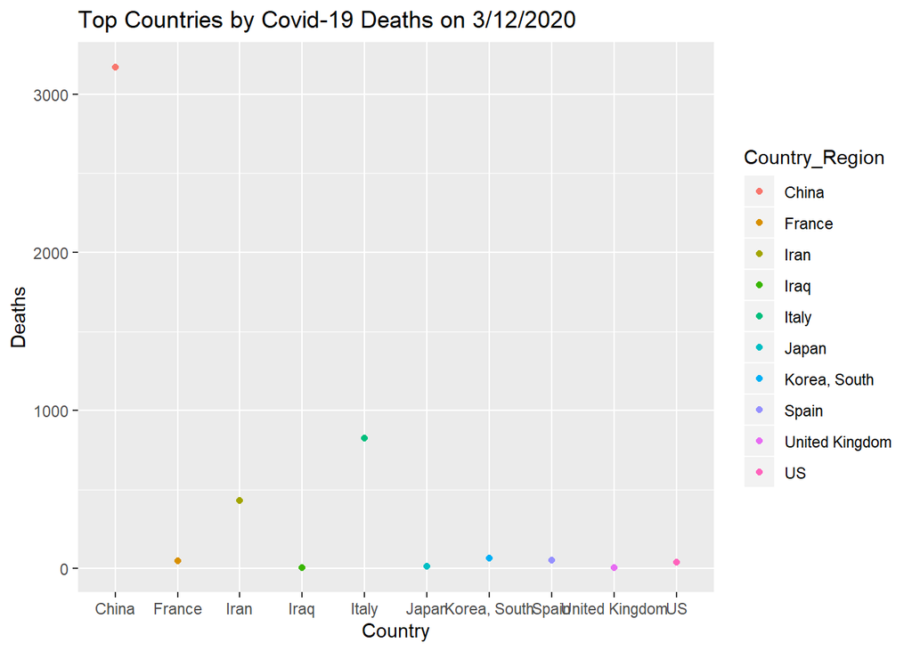

```r
top_deaths10_3_12 = report_03_12_2020 %>%
  group_by(Country_Region) %>%
  summarise(Deaths = sum(Deaths)) %>%
  arrange(desc(Deaths)) %>%
  slice(0:10)

top_confirmed10_3_12 = report_03_12_2020 %>%
  group_by(Country_Region) %>%
  summarise(Confirmed = sum(Confirmed)) %>%
  arrange(desc(Confirmed)) %>%
  slice(0:10)

top_deaths10_9_12 = report_09_12_2020 %>%
  group_by(Country_Region) %>%
  summarise(Deaths = sum(Deaths)) %>%
  arrange(desc(Deaths)) %>%
  slice(0:10)

top_confirmed10_9_12 = report_09_12_2020 %>%
  group_by(Country_Region) %>%
  summarise(Confirmed = sum(Confirmed)) %>%
  arrange(desc(Confirmed)) %>%
  slice(0:10)

ggplot(data = top_deaths10_3_12, mapping = aes(x = Country_Region, y = Deaths, xlab='Country', ylab='Deaths')) +
    geom_point(aes(color = Country_Region)) + ggtitle("Top Countries by Covid-19 Deaths on 3/12/2020") + xlab('Country') + ylab('Deaths')
```

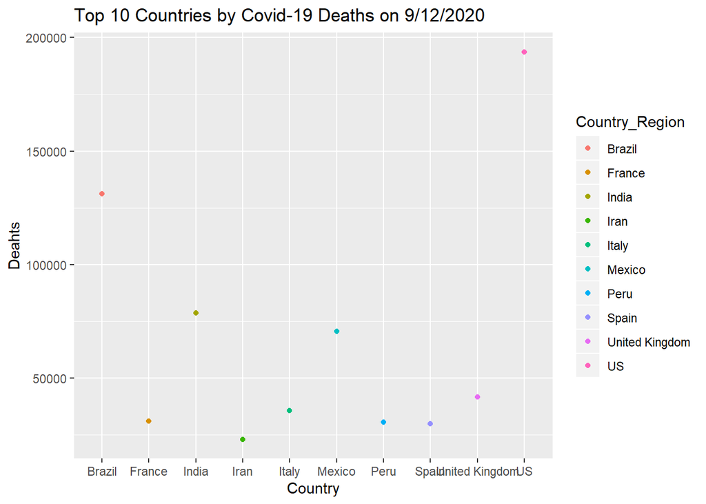

```r
ggplot(data = top_deaths10_9_12, mapping = aes(x = Country_Region, y = Deaths, xlab='Country', ylab='Deaths')) +
    geom_point(aes(color = Country_Region)) + ggtitle("Top 10 Countries by Covid-19 Deaths on 9/12/2020") + xlab('Country') + ylab('Deahts')
```

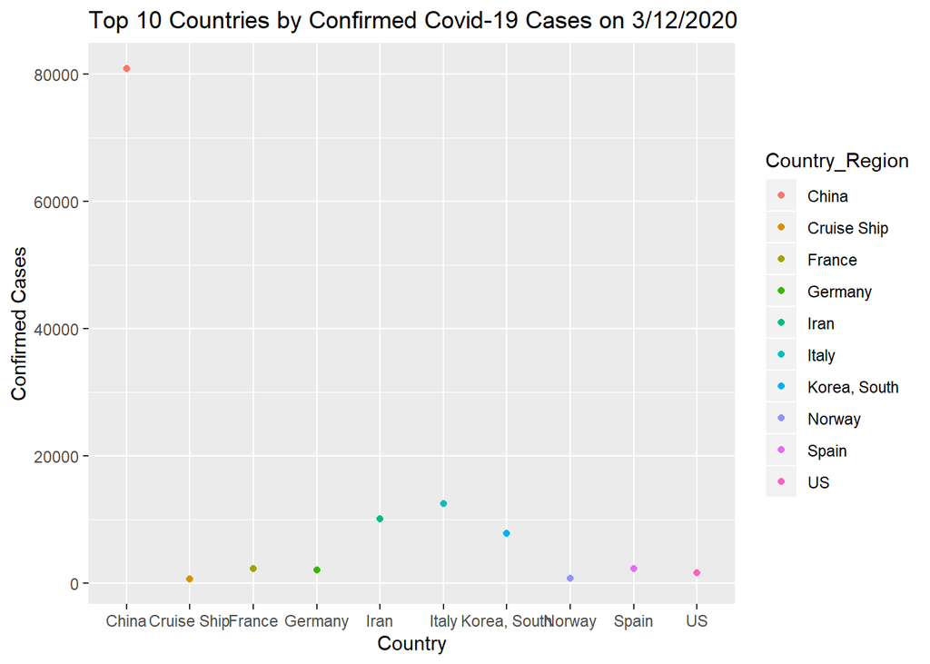

```r
ggplot(data = top_confirmed10_3_12, mapping = aes(x = Country_Region, y = Confirmed, xlab='Country', ylab='Confirmed')) +
    geom_point(aes(color = Country_Region)) + ggtitle("Top 10 Countries by Confirmed Covid-19 Cases on 3/12/2020") + xlab('Country') + ylab('Confirmed Cases')
```

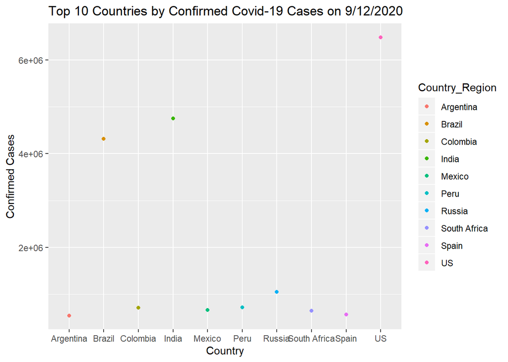

```r
ggplot(data = top_confirmed10_9_12, mapping = aes(x = Country_Region, y = Confirmed, xlab='Country', ylab='Confirmed Cases')) +
    geom_point(aes(color = Country_Region)) + ggtitle("Top 10 Countries by Confirmed Covid-19 Cases on 9/12/2020") + xlab('Country') + ylab('Confirmed Cases')
```

## Exercise 6

```r
ConfirmedByStateTop10_3 = report_03_12_2020 %>%
  filter(Country_Region == "US") %>%
  group_by(Province_State) %>%
  summarize(ConfirmedCases = sum(Confirmed)) %>%
  arrange(desc(ConfirmedCases)) %>%
  slice(0:10)


ConfirmedByStateTop10_9 = report_09_12_2020 %>%
  filter(Country_Region == "US") %>%
  group_by(Province_State) %>%
  summarize(ConfirmedCases = sum(Confirmed)) %>%
  arrange(desc(ConfirmedCases)) %>%
  slice(0:10)

DeathsByStateTop10_3 = report_03_12_2020 %>%
  filter(Country_Region == "US") %>%
  group_by(Province_State) %>%
  summarize(Deaths = sum(Deaths)) %>%
  arrange(desc(Deaths)) %>%
  slice(0:10)

DeathsByStateTop10_9 = report_09_12_2020 %>%
  filter(Country_Region == "US") %>%
  group_by(Province_State) %>%
  summarize(Deaths = sum(Deaths)) %>%
  arrange(desc(Deaths)) %>%
  slice(0:10)
```

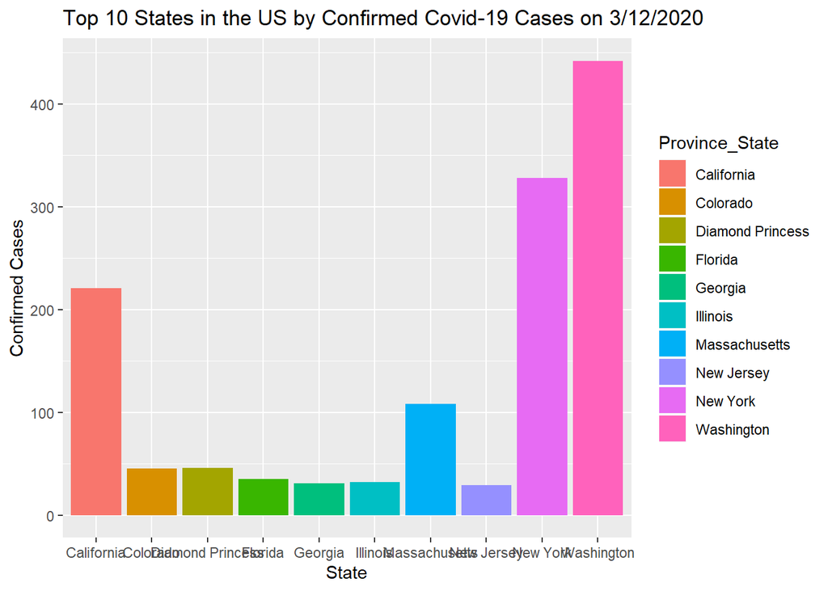

```r
ggplot(data = ConfirmedByStateTop10_3, aes(x = Province_State, y  = ConfirmedCases)) + geom_bar(stat = "identity", aes(fill = Province_State)) + ggtitle("Top 10 States in the US by Confirmed Covid-19 Cases on 3/12/2020") + xlab("State") + ylab("Confirmed Cases")
```

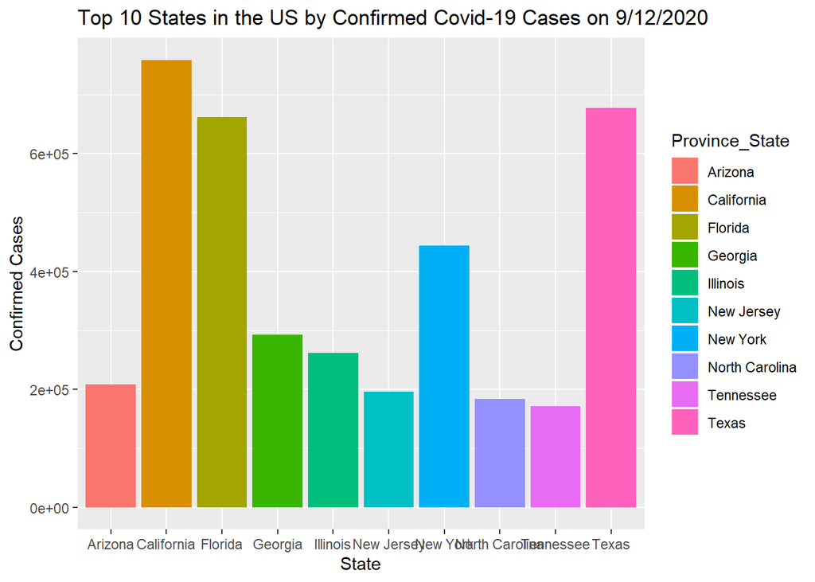

```r
ggplot(data = ConfirmedByStateTop10_9, aes(x = Province_State, y  = ConfirmedCases)) + geom_bar(stat = "identity", aes(fill = Province_State)) + ggtitle("Top 10 States in the US by Confirmed Covid-19 Cases on 9/12/2020") + xlab("State") + ylab("Confirmed Cases")
```

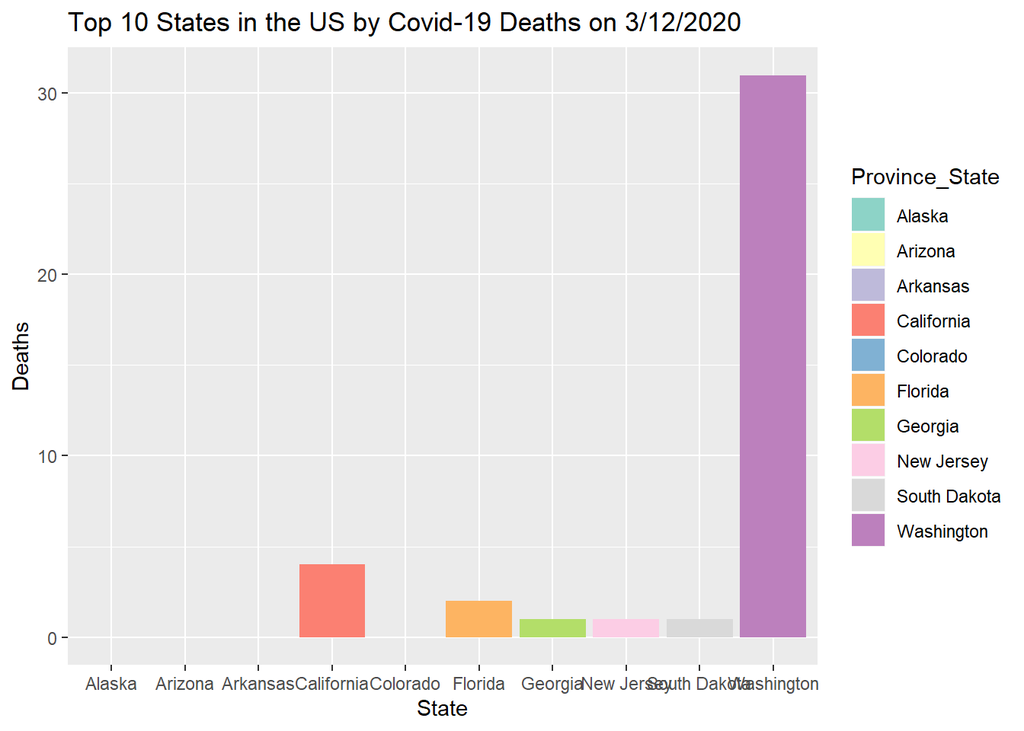

```r
ggplot(data = DeathsByStateTop10_3, aes(x = Province_State, y  = Deaths)) + geom_bar(stat = "identity", aes(fill = Province_State)) + ggtitle("Top 10 States in the US by Covid-19 Deaths on 3/12/2020") + xlab("State") + ylab("Deaths") + scale_fill_brewer(palette='Set3')
```

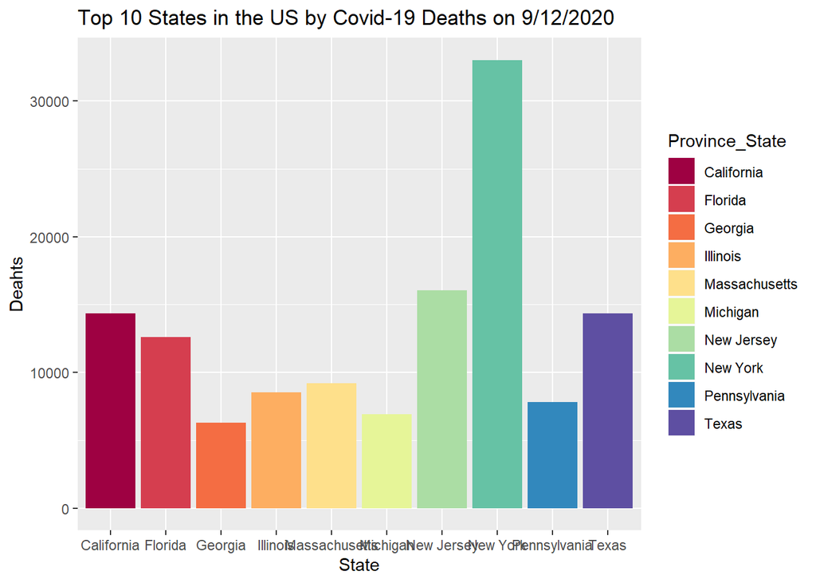

```r
ggplot(data = DeathsByStateTop10_9, aes(x = Province_State, y  = Deaths)) + geom_bar(stat = "identity", aes(fill = Province_State)) + ggtitle("Top 10 States in the US by Covid-19 Deaths on 9/12/2020") + xlab("State") + ylab("Deahts") + scale_fill_brewer(palette='Spectral')
```

For the final graph, since on 3/12 there were only 6 states that had Covid-19 related deaths, there are various states on the graphs that do not have a single death.